# Hierarchical logistic regression models in Stan

```r
library("rstan")
library("ggplot2")
library("bayesplot")
library("dplyr")
```

```r
options(mc.cores = parallel::detectCores())
```

### Load and look at the data

```r
cps <- readRDS('cps_2016.RDS')
pstrat <- readRDS('frame.RDS')
```

```r
head(cps)
```

```
## # A tibble: 6 x 9
##       age gender state   eth            edu       marstat  vote     N
##    <fctr>  <chr> <chr> <chr>          <chr>         <chr> <int> <int>
## 1 [18,21) Female    AL Black    High School Never married     3     4
## 2 [18,21) Female    AL Black No High School Never married     1     2
## 3 [18,21) Female    AL Black   Some College Never married     3     4
## 4 [18,21) Female    AL Other   Some College Never married     0     1
## 5 [18,21) Female    AL White    High School       Married     1     1
## 6 [18,21) Female    AL White    High School Never married     2     6
## # ... with 1 more variables: state_pres_vote <dbl>
```

```r
head(pstrat)
```

```
## # A tibble: 6 x 10
##       age gender state      eth            edu       marstat female N_elig
##    <fctr>  <chr> <chr>    <chr>          <chr>         <chr>  <dbl>  <int>
## 1 [18,21) Female    AK    Black    High School Never married    0.5     73
## 2 [18,21) Female    AK    Black No High School Never married    0.5     48
## 3 [18,21) Female    AK    Black   Some College       Married    0.5    155
## 4 [18,21) Female    AK Hispanic    High School       Married    0.5     33
## 5 [18,21) Female    AK Hispanic    High School Never married    0.5    681
## 6 [18,21) Female    AK Hispanic No High School Never married    0.5    254
## # ... with 2 more variables: N <int>, state_pres_vote <dbl>
```

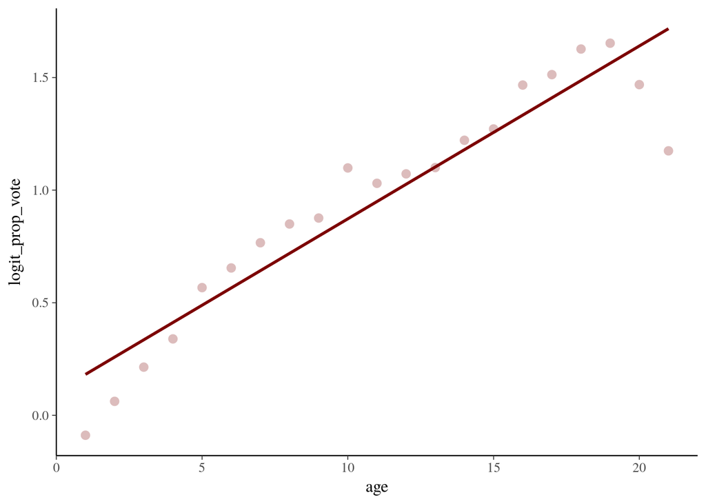

```r
theme_set(bayesplot::theme_default())

cps %>%
  group_by(age) %>%
  summarise(
    logit_prop_vote = qlogis(sum(vote) / sum(N))
  ) %>%
  ungroup() %>%
  mutate(age = as.integer(as.factor(age))) -> cps_plot


p <- ggplot(cps_plot, aes(x = age, y = logit_prop_vote))
p1 <- p + geom_point(size = 2.5, color = "#DCBCBC") +
  geom_smooth(method = "lm", se = FALSE, color = "#7C0000")
p1
```

Let’s fit a simple model to the data:

```r
cps %>%
  group_by(age,state) %>%
  summarise(
    y = sum(vote),
    K = sum(N)
  ) %>% ungroup() %>%
  mutate(
    idx_age = fac2int(age),
    idx_state = fac2int(state)
  ) -> cps_fit_1
N <- nrow(cps_fit_1)
y <- cps_fit_1$y
K <- cps_fit_1$K
idx_age <- cps_fit_1$idx_age
idx_state <- cps_fit_1$idx_state
J_age <- n_levels(idx_age)
J_state <- n_levels(idx_state)
```

```r
mod1 <- stan_model('binom_vote_state_age.stan')
```

[output not shown]

```r
stan_dat <- list(N = N, y = y, K = K,
                 J_age = J_age, J_state = J_state,
                 idx_age = idx_age, idx_state = idx_state)
fit1 <- sampling(mod1, data = stan_dat, iter = 1000, seed = 123)
```

Examine the fit:

```r
print(fit1, pars = c('sigma_age','sigma_state'))
```

```
## Inference for Stan model: binom_vote_state_age.
## 4 chains, each with iter=1000; warmup=500; thin=1;
## post-warmup draws per chain=500, total post-warmup draws=2000.
##
##             mean se_mean   sd 2.5%  25%  50%  75% 97.5% n_eff Rhat
## sigma_age   0.54    0.01 0.10 0.39 0.48 0.53 0.60  0.77   277 1.02
## sigma_state 0.25    0.00 0.03 0.20 0.23 0.25 0.26  0.31   287 1.03
##
## Samples were drawn using NUTS(diag_e) at Mon Aug 14 16:05:11 2017.
## For each parameter, n_eff is a crude measure of effective sample size,
## and Rhat is the potential scale reduction factor on split chains (at
## convergence, Rhat=1).
```

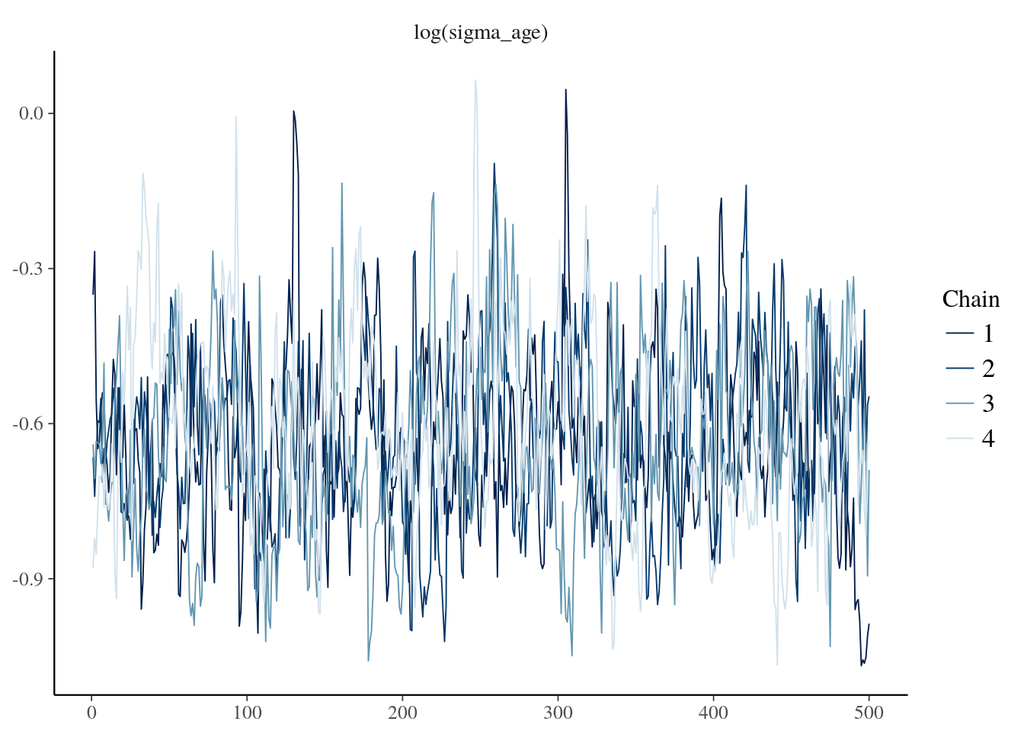

```r
post_draws_1 <- rstan::extract(fit1, pars = c('sigma_age','alpha'), permute = F)
mcmc_trace(post_draws_1, pars = 'sigma_age', transformations = list(sigma_age = "log"))
```

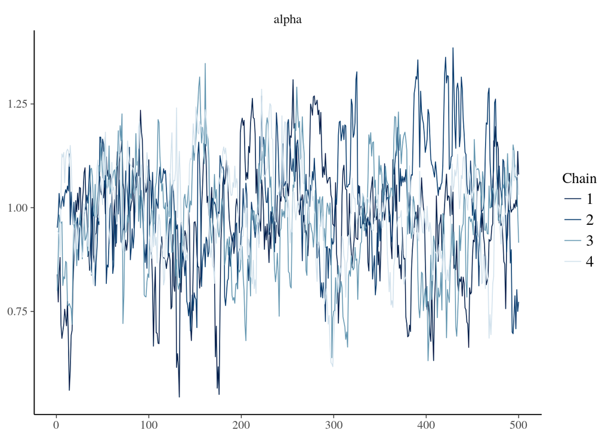

```r
mcmc_trace(post_draws_1, pars = 'alpha')
```

## Control parameters

The fit looks good, but let’s try to fit the same model and change the target Metropolis accpetance rate during the warmup by changing the control parameter

```r
mod1_refit <- sampling(mod1, data = stan_dat, iter = 1000, seed = 123,
                       control = list(adapt_delta = 0.99, max_treedepth = 12))
```

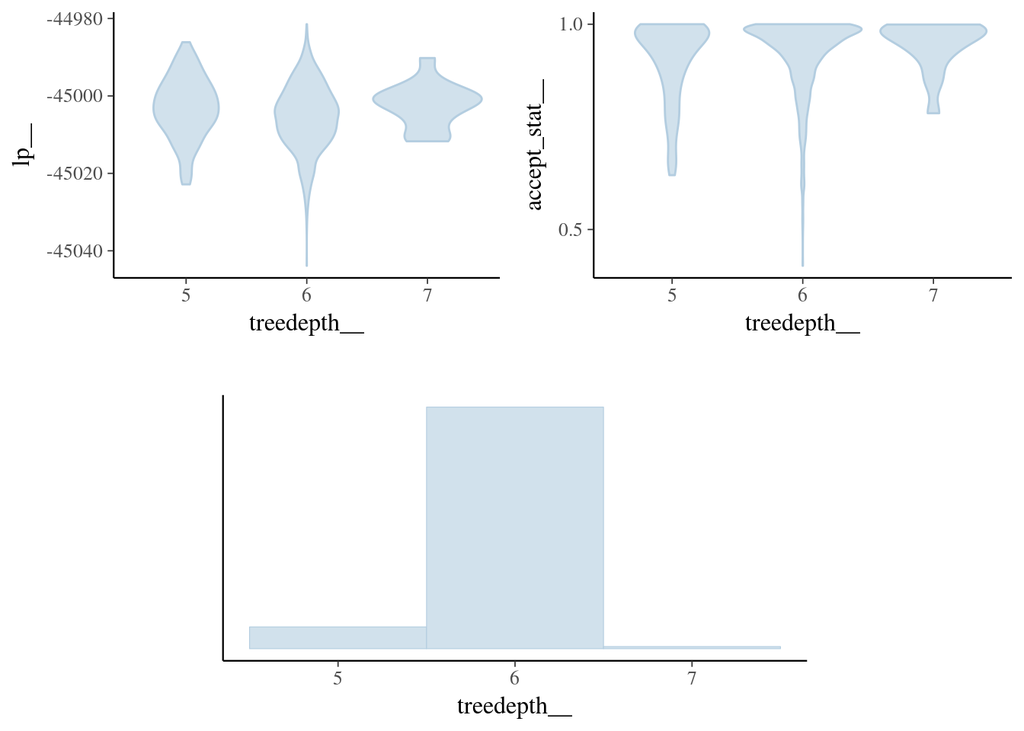

```r
np_orig <- nuts_params(fit1)
lp_orig <- log_posterior(fit1)
np_refit <- nuts_params(mod1_refit)
lp_refit <- log_posterior(mod1_refit)

mcmc_nuts_treedepth(np_orig, lp = lp_orig)
```

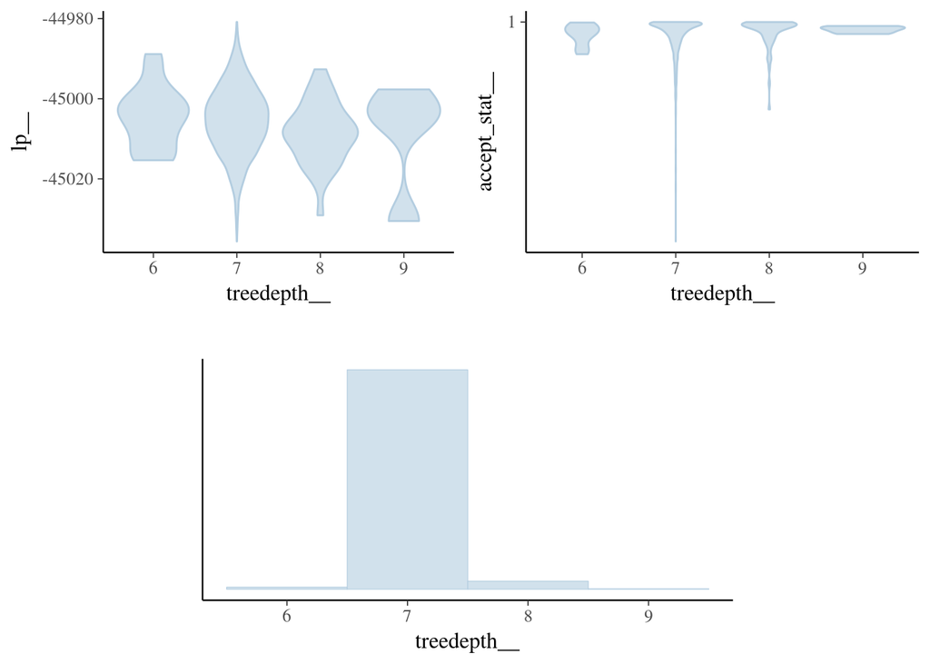

```r
mcmc_nuts_treedepth(np_refit, lp = lp_refit)
```

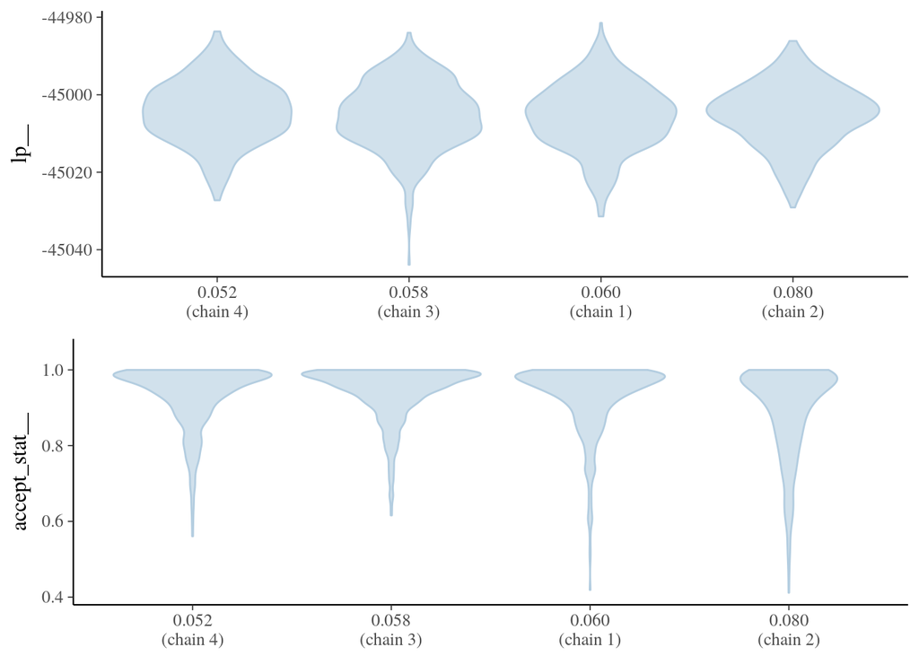

```r
mcmc_nuts_stepsize(np_orig, lp = lp_orig)
```

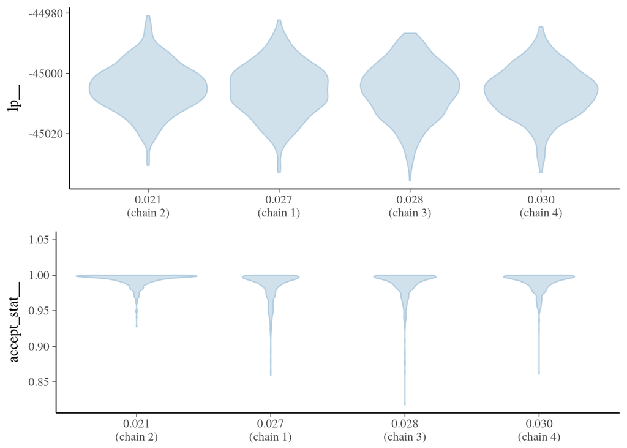

```r
mcmc_nuts_stepsize(np_refit, lp = lp_refit)
```

This will take longer, and our treedepth should increase. Why might that happen?

We should keep these control parameters in mind for when our models become more complex in order to fit complex data, we’ll often need to boost adapt_delta to force Stan to take smaller steps after warmup.

## Poststrat addition

```r
stan_to_state <- unique(cps_fit_1[,c('state','idx_state')])
stan_to_age <- unique(cps_fit_1[,c('age','idx_age')])
ps_state_set <- unique(pstrat$state)
missing_states <- setdiff(ps_state_set, stan_to_state$state)
idx_missing <- max(stan_to_state$idx_state) + fac2int(missing_states)
stan_to_state = bind_rows(stan_to_state,
                          data.frame(state = missing_states,
                                     idx_state = idx_missing))
pstrat %>%
  group_by(
    age, state
  ) %>%
  summarise(
    cell_elig = sum(N_elig)
  ) %>% ungroup() %>%
  mutate(
    idx_age = as.integer(plyr::mapvalues(age,
                                         from = stan_to_age$age,
                                         to = stan_to_age$idx_age)),
    idx_state = as.integer(plyr::mapvalues(state,
                                           from = stan_to_state$state,
                                           to = stan_to_state$idx_state))
  )-> pstrat_1
idx_age_ps <- pstrat_1$idx_age
idx_state_ps <- pstrat_1$idx_state
N_ps <- nrow(pstrat_1)
cell_elig <- pstrat_1$cell_elig
```

```r
mod2 <- stan_model('binom_vote_pstrat.stan')
```

[output not shown]

```r
stan_dat_pstrat <- stan_dat
stan_dat_pstrat$N_ps <- N_ps
stan_dat_pstrat$cell_elig <- cell_elig
stan_dat_pstrat$idx_age_ps <- idx_age_ps
stan_dat_pstrat$idx_state_ps <- idx_state_ps

fit2 <- sampling(mod2, data = stan_dat_pstrat, iter = 1000, seed = 234)
```

## Add state-level predictors to handle sparse data

Given that we won’t have good estimates for the state effect of Alaska and Hawaii, we should add state-level predictors. We’ll use the polling average by state.

Add the predictors age and state_pres_vote. The model will be:

$$y_n \sim \text{Binomial}(K_n, p_n) \\
\text{logit}(p_n) = \alpha + \alpha^\text{age}_{j[n]} + \alpha^\text{state}_{k[n]} +
X_n \times \beta\\
\alpha^\text{age}_j = \sigma_{\text{age}} \times \eta^\text{age}_j \\
\alpha^\text{state}_k = \sigma_{\text{state}} \times \eta^\text{state}_k \\
\alpha^\text{age}_j, \alpha^\text{state}_k \sim \text{Normal}(0, 1) \\
\sigma_\text{age}, \sigma_\text{state} \sim \text{Normal}^+(0, 1)$$

where $X_n$ is a row-vector from the $N$ by $D$ matrix $X$.

### QR reparameterization

```r
cps %>%
  group_by(age,state) %>%
  summarise(
    y = sum(vote),
    K = sum(N),
    state_pres_vote = first(state_pres_vote)
  ) %>% ungroup() %>%
  mutate(
    idx_age = fac2int(age),
    idx_state = fac2int(state)
  )-> cps_fit_2
N <- nrow(cps_fit_2)
y <- cps_fit_2$y
K <- cps_fit_2$K
idx_age <- cps_fit_2$idx_age
idx_state <- cps_fit_2$idx_state
J_age <- n_levels(idx_age)
J_state <- n_levels(idx_state)
state_pres_vote <- cps_fit_2$state_pres_vote
X <- cbind(state_pres_vote, idx_age)
c_means <- colMeans(X)
X_cent <- sweep(x = X, MARGIN = 2, STATS = c_means)
QR <- qr(X_cent)
Q <- qr.Q(QR)
R <- qr.R(QR)
sqrtN = sqrt(nrow(X) - 1)
Q_scale = Q * sqrtN
R_scale = R * 1 / sqrtN
R_inv = solve(R_scale)

pstrat %>%
  group_by(
    age, state
  ) %>%
  summarise(
    cell_elig = sum(N_elig),
    state_pres_vote = first(state_pres_vote)
  ) %>% ungroup() %>%
  mutate(
    idx_age = as.integer(plyr::mapvalues(age,
                                         from = stan_to_age$age,
                                         to = stan_to_age$idx_age)),
    idx_state = as.integer(plyr::mapvalues(state,
                                           from = stan_to_state$state,
                                           to = stan_to_state$idx_state))
  )-> pstrat_2
idx_age_ps <- pstrat_2$idx_age
idx_state_ps <- pstrat_2$idx_state
N_ps <- nrow(pstrat_2)
cell_elig <- pstrat_2$cell_elig
state_pres_vote_ps <- pstrat_2$state_pres_vote
age_vec <- pstrat_2$idx_age
```

What’s going on with lines 157 through 162? Remember that a QR decomposition will decompose any $N$ by $D$ matrix $X$ into matrices $Q$ and $R$, where $Q$ is an $N$ by $D$ matrix whose columns are orthogonal and $R$ is a square $D$ by $D$ matrix. This transformation from $X$ to $Q$ is the multivariate version of scaling a variable. It ensures that the posterior density for $\beta$ is not affected by the correlation of the columns of $X$.

How will this affect our inference for $\beta$? We can see through some algebra:

$$X = Q \times R \\
\text{logit}(p) = X \times \beta + \dots \\
\text{logit}(p) = Q \times R \times \beta + \dots \\$$
setting $\gamma = R \times \beta$ yields

$$\text{logit}(p) = Q \times \gamma + \dots \\$$

and we can get back to $\beta$ by solving for $\beta$: $\beta = R^{-1} \times \gamma$.

```r
mod3 <- stan_model('binom_vote_reg.stan')
```

[output not shown]

```r
stan_dat <- list(N = N, y = y, K = K, D = dim(X)[2],
                 J_age = J_age, J_state = J_state,
                 idx_age = idx_age, idx_state = idx_state,
                 Q_scale = Q_scale, R_inv = R_inv, c_means = c_means,
                 cell_elig = cell_elig, N_ps = N_ps, idx_age_ps = idx_age_ps, idx_state_ps = idx_state_ps,
                 age_vec_ps = age_vec, state_pres_vote_ps = state_pres_vote_ps)
fit3 <- sampling(mod3, data = stan_dat, iter = 1000, seed = 123)
```

```r
print(fit3,pars = c('alpha','beta','gamma','sigma_age','sigma_state'))
```

```
## Inference for Stan model: binom_vote_reg.
## 4 chains, each with iter=1000; warmup=500; thin=1;
## post-warmup draws per chain=500, total post-warmup draws=2000.
##
##             mean se_mean   sd 2.5%  25%  50%  75% 97.5% n_eff Rhat
## alpha       0.98    0.00 0.05 0.88 0.94 0.98 1.02  1.08   394 1.02
## beta[1]     1.29    0.02 0.37 0.59 1.04 1.29 1.53  2.03   449 1.01
## beta[2]     0.08    0.00 0.01 0.06 0.07 0.08 0.08  0.09   428 1.01
## gamma[1]    0.12    0.00 0.03 0.05 0.09 0.12 0.14  0.18   449 1.01
## gamma[2]    0.47    0.00 0.04 0.39 0.45 0.47 0.50  0.56   428 1.01
## sigma_age   0.19    0.00 0.03 0.14 0.17 0.19 0.21  0.27   507 1.00
## sigma_state 0.22    0.00 0.03 0.17 0.20 0.21 0.23  0.27   440 1.02
##
## Samples were drawn using NUTS(diag_e) at Mon Aug 14 16:07:43 2017.
## For each parameter, n_eff is a crude measure of effective sample size,
## and Rhat is the potential scale reduction factor on split chains (at
## convergence, Rhat=1).
```

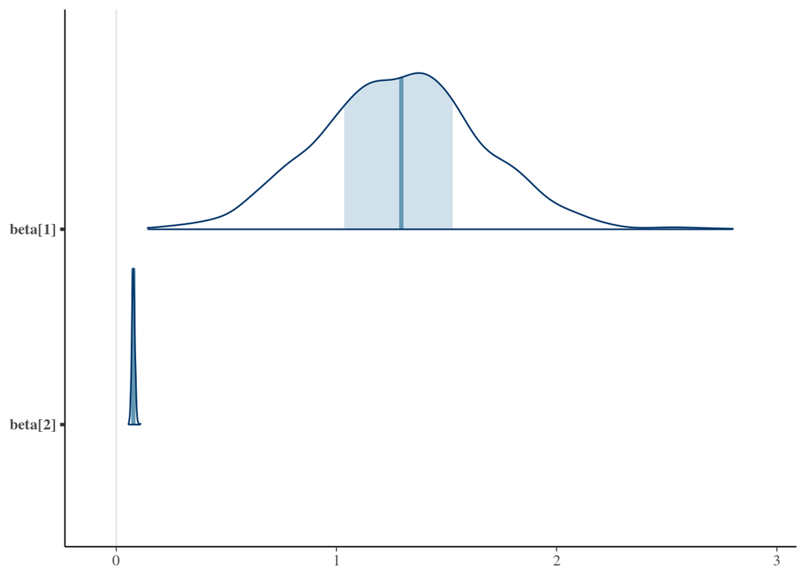

```r
post_draws_3 <- rstan::extract(fit3,
                               pars = c('alpha','beta','gamma','sigma_age','sigma_state'),
                               permute = F)
mcmc_areas(post_draws_3, regex_pars = 'beta')
```

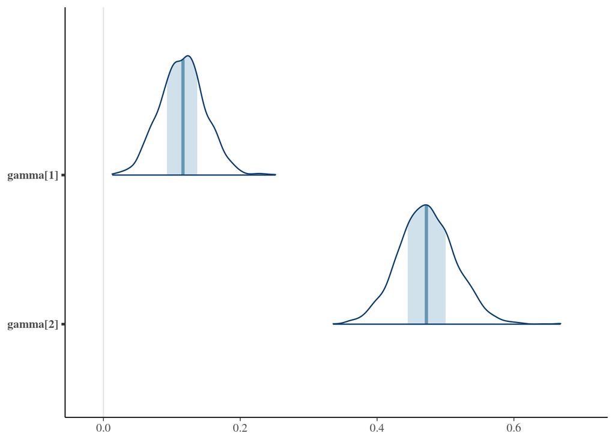

```r
mcmc_areas(post_draws_3, regex_pars = 'gamma')
```

Plot the predicted proportions for age vs. realized proportions:

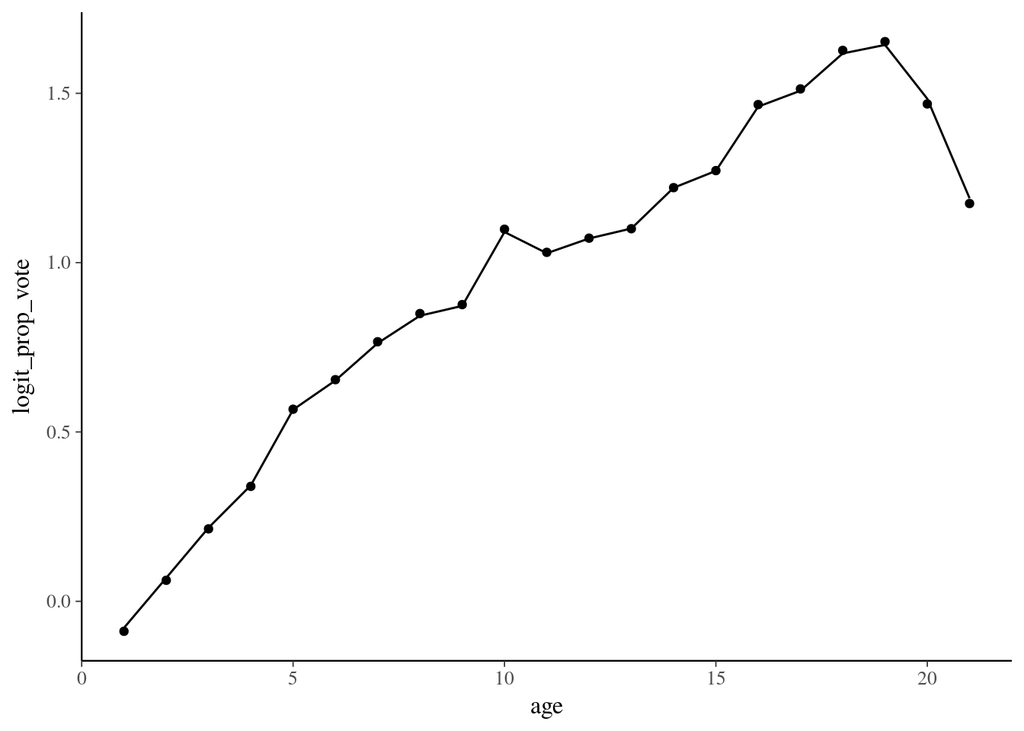

```r
samps <- rstan::extract(fit3, pars = c('age_prop'))
df <- cps_plot %>%
  mutate(
    mod_pred_age = qlogis(colMeans(samps$age_prop))
  )
df1 <- df[,c('age','logit_prop_vote')]
df2 <- df[,c('age','mod_pred_age')]

ggplot(df1, aes(x = age, y = logit_prop_vote)) +
  geom_point() + geom_line(data = df2, aes(x = age, y = mod_pred_age))
```

## Hierarchical scale parameters

Thus far we’ve been using half-normal priors for all of our hierarchical variance parameters. We could continue adding random intercepts conditioned on grouping factors along with the half-normal priors:

$$\sigma_\text{age} \sim \text{Normal}^+(0, 1) \\
\sigma_\text{state} \sim \text{Normal}^+(0, 1) \\
\sigma_\text{edu} \sim \text{Normal}^+(0, 1) \\
\sigma_\text{eth} \sim \text{Normal}^+(0, 1)$$

$$\pi \sim \text{Dirichlet}(\nu) \\
\sigma_\text{global} \sim \text{exponential}(1) \\
\vec{\sigma} = \sqrt{c \times \pi \times \sigma_\text{global}^2}$$

The prior allows us to encode our prior beliefs about the variance of the random intercepts separately from the proportion of variance attributed to each component.

Let’s write the last model, but with the ANOVA prior.

```r
mod4 <- stan_model('binom_vote_reg_anova_prior.stan')
```

[output not shown]

```r
cps %>%
  group_by(age,state,edu) %>%
  summarise(
    y = sum(vote),
    K = sum(N),
    state_pres_vote = first(state_pres_vote)
  ) %>% ungroup() %>%
  mutate(
    idx_age = fac2int(age),
    idx_state = fac2int(state),
    idx_edu = fac2int(edu)
  ) -> cps_fit_3
N <- nrow(cps_fit_3)
y <- cps_fit_3$y
K <- cps_fit_3$K
idx_age <- cps_fit_3$idx_age
idx_state <- cps_fit_3$idx_state
idx_edu <- cps_fit_3$idx_edu
J_age <- n_levels(idx_age)
J_state <- n_levels(idx_state)
J_edu <- n_levels(idx_edu)
state_pres_vote <- cps_fit_3$state_pres_vote
X <- cbind(state_pres_vote, idx_age)
c_means <- colMeans(X)
X_cent <- sweep(x = X, MARGIN = 2, STATS = c_means)
QR <- qr(X_cent)
Q <- qr.Q(QR)
R <- qr.R(QR)
sqrtN = sqrt(nrow(X) - 1)
Q_scale = Q * sqrtN
R_scale = R * 1 / sqrtN
R_inv = solve(R_scale)

stan_to_edu <- unique(cps_fit_3[,c('edu','idx_edu')])
pstrat %>%
  group_by(
    age, state, edu
  ) %>%
  summarise(
    cell_elig = sum(N_elig),
    state_pres_vote = first(state_pres_vote)
  ) %>% ungroup() %>%
  mutate(
    idx_age = as.integer(plyr::mapvalues(age,
                                         from = stan_to_age$age,
                                         to = stan_to_age$idx_age)),
    idx_state = as.integer(plyr::mapvalues(state,
                                           from = stan_to_state$state,
                                           to = stan_to_state$idx_state)),
    idx_edu = as.integer(plyr::mapvalues(edu,
                                           from = stan_to_edu$edu,
                                           to = stan_to_edu$idx_edu))
  )-> pstrat_3
idx_age_ps <- pstrat_3$idx_age
idx_state_ps <- pstrat_3$idx_state
N_ps <- nrow(pstrat_3)
cell_elig <- pstrat_3$cell_elig
state_pres_vote_ps <- pstrat_3$state_pres_vote
age_vec <- pstrat_3$idx_age
```

We have the data ready but we won’t fit it because it’ll be a bit too slow to do in class.

Let’s move to rstanarm to see how we’d fit the same model and do some more interesting poststrat.